# Prob3cp1

# Agrupamento com filmes de Jim Carrey

Usaremos dados do [Rotten Tomatoes](https://www.rottentomatoes.com) sobre os filmes de Jim Carrey

O tipo de pergunta que queremos responder com agrupamento é *existem tipos de filmes claramente diferentes em termos de sucesso na crítica e público dentre os feitos por Jim Carrey?*

```
## # A tibble: 14 x 5
##    avaliacao filme                papel                   bilheteria   ano
##        <int> <chr>                <chr>                        <dbl> <int>
##  1        33 Kick-Ass 2           Colonel Stars and Stri…       28.9  2013
##  2        37 The Incredible Burt… Steve Gray                    22.6  2013
##  3        47 Mr. Popper's Pengui… Mr. Popper                    68.2  2011
##  4        72 I Love You Phillip … Steven Russell                 2.1  2010
##  5        54 Disney's A Christma… Scrooge/Ghosts of Chri…      138.   2009
##  6        94 Under the Sea 3D     Narrator                      35.1  2009
##  7        46 Yes Man              Carl Allen                    97.7  2008
##  8        79 Dr. Seuss' Horton H… Horton                       154.   2008
##  9         8 The Number 23        Walter Sparrow/Det. Fi…       35.1  2007
## 10        29 Fun With Dick and J… Dick Harper  Producer        110.   2005
## 11        71 Lemony Snicket's A … Count Olaf                   118.   2004
## 12        93 Eternal Sunshine Of… Joel Barish                   34.2  2004
## 13        49 Bruce Almighty       Bruce Nolan  Producer        243.   2003
## 14        53 Dr. Seuss' How the … The Grinch                   259.   2000
```

São 14 filmes com avaliações bem variadas. Os filmes em que Jim Carrey participa variam de humor para drama. Provavelmente essa mudança deve ser refletida nas bilheterias.

Fazendo agrupamentos com os filmes por suas diferenças de avaliação e bilheteria, vemos que é interessante gerar algumas visualizações para que possa ficar mais visível a similaridade.

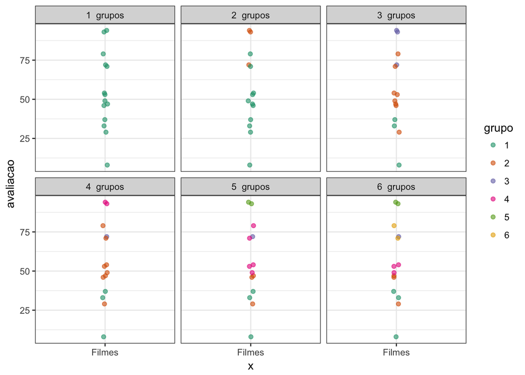

De modo geral, a divisão em 5 grupos deixa os dados de forma mais amigável para uma análise:

[interactive chart not shown]

- Grupo 1: Vemos os filme que não foram sucesso de crítica nem muito menos de bilheteria. Poderiamos chamá-los de ‘Show de Horror’
- Grupo 2: Filme estilo sessão da tarde. Não é um sucesso absoluto mas também não são ruins.
- Grupo 3: Todo ator tem aquele filme cult que é até legal mas não vende nada, não é mesmo?
- Grupo 4: Estes são o que salvam o dia. São os filmes razoavelmente bem avaliados mas que possuem as maiores bilheterias. Tem uma maior proporção na carreira do Jim Carrey.
- Grupo 5: Apesar de excelentes em crítica, os dois filmes restantes não foram sucesso de público. Curioso que `Eternal Sunshine of The Spotless Mind` é um filme bastante visto atualmente.